# Reto2

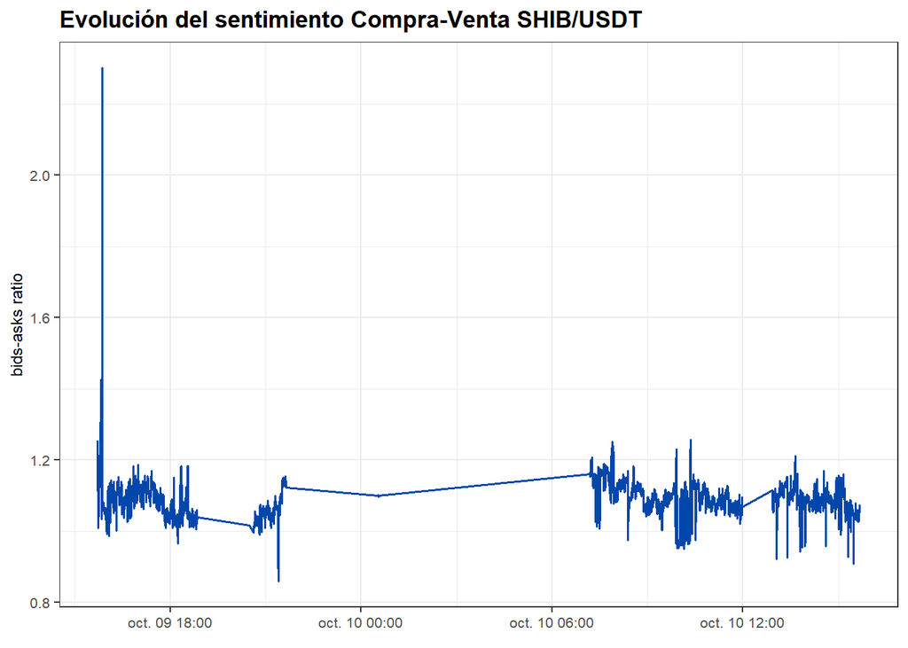

```r
grafica_evolucion_compra_venta(datos_SHIB_USDT, "10 sec", "Evolución del sentimiento Compra-Venta SHIB/USDT", "bids-asks ratio")
```

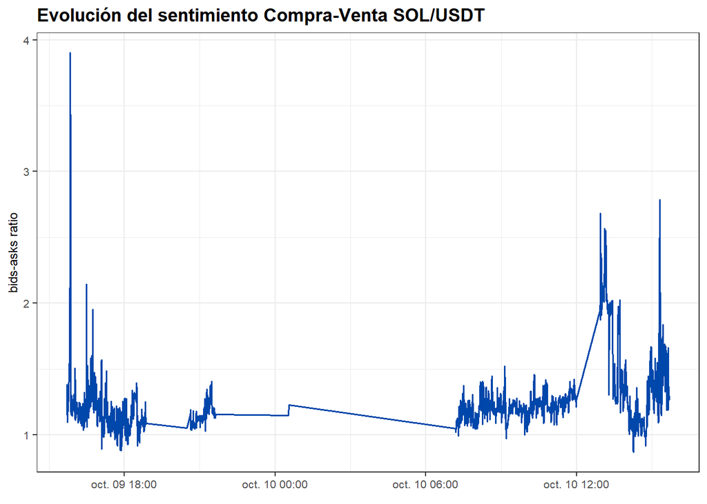

```r
grafica_evolucion_compra_venta(datos_SOL_USDT, "10 sec", "Evolución del sentimiento Compra-Venta SOL/USDT", "bids-asks ratio")
```

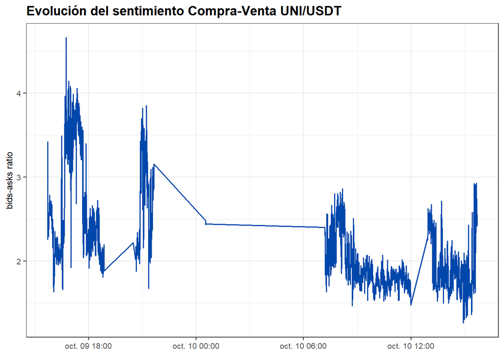

```r
grafica_evolucion_compra_venta(datos_UNI_USDT, "10 sec", "Evolución del sentimiento Compra-Venta UNI/USDT", "bids-asks ratio")
```

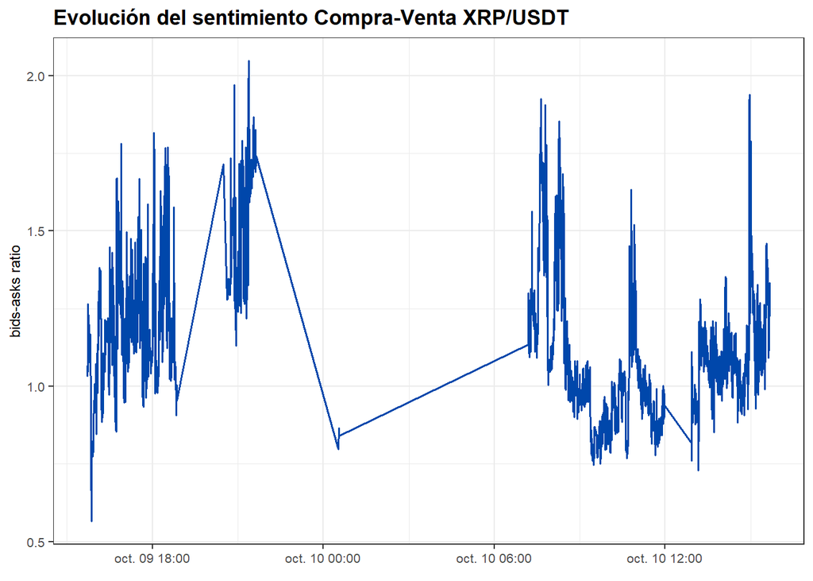

```r
grafica_evolucion_compra_venta(datos_XRP_USDT, "10 sec", "Evolución del sentimiento Compra-Venta XRP/USDT", "bids-asks ratio")
```

## Apéndice de funciones auxilliares y operaciones realizadas para transformar los csv iniciales en los ficheros que finalmente cargamos.

A continuación se muestran las funciones auxilliares y operaciones realizadas para transformar los csv iniciales en los ficheros que finalmente cargamos dentro de este fichero.

Por temas de rendimiento y memoria hemos tenido que realizar un preprocesamiento de los datos hasta tenerlos en el formato con el que vamos a trabajar y que mostramos al inicio de este documento.

Carga de las monedas en un único dataset

```r
# info_cuantitativa <-
#   list.files(path = 'Data/información_cuantitava_monedas_reto2', pattern = "*.csv", full.names = TRUE, recursive = TRUE) %>%
#   map_df(~fread(.x))
#
# str(info_cuantitativa)
```

Aquí ponemos nombres a las columnas y hacemos un dataset por cada divisa (A modo de ejemplo ponemos el de BTC)

```r
# colnames(info_cuantitativa) <- c("Hora", "Exchange","Divisa", "Datos")
# infoBTCUSD<-info_cuantitativa[info_cuantitativa$Divisa == 'BTC/USDT']
```

Aquí calculamos para cada dataframe los valores que luego vamos a utilizar para el análisis y que luego nos permiten eliminar las columnas con las listas, que ocupan demasiada memoria.

```r
#
#  for (i in 1:nrow(info_symbol)){
#    info_symbol$mediaBids[i] <- mean(info_symbol$bids[[i]][,1])
#    info_symbol$profundidad[i] <- sum(info_symbol$bids[[i]][,2])
#    info_symbol$mediaAsks[i] <- mean(info_symbol$asks[[i]][,1])
#    info_symbol$profundidadAsks[i] <- sum(info_symbol$asks[[i]][,2])
#  }
#
#
# info_symbol <- info_symbol %>%
#    arrange(Exchange, Hora) %>%
#    mutate(varPrecioMedioBids = 100 * (mediaBids - lag(mediaBids)) / lag(mediaBids)) %>%
#    mutate(varProfundidadBids = 100 * (mediaBids - lag(profundidad)) / lag(profundidad)) %>%
#    mutate(varPrecioMedioAsks = 100 * (mediaBids - lag(mediaAsks)) / lag(mediaAsks)) %>%
#    mutate(varProfundidadAsks = 100 * (mediaAsks - lag(profundidadAsks)) / lag(profundidadAsks))%>%
#    mutate(tiempoLlegada = (Hora - lag(Hora))) %>%
#    mutate(sentimientoCompraVenta = (profundidad / profundidadAsks))
#
# #Eliminamos las listas
# info_symbol<-select(info_symbol, -2:-3)
```

```r
# save(datos_ADA_USDT, file=paste("crypto_orderbooks_", "agregados_ADA_USDT.Rda", sep = ""))
# save(datos_AVAX_USDT, file=paste("crypto_orderbooks_", "agregados_AVAX_USDT.Rda", sep = ""))
# save(datos_BTC_USDT, file=paste("crypto_orderbooks_", "agregados_BTC_USDT.Rda", sep = ""))
# save(datos_DOT_USDT, file=paste("crypto_orderbooks_", "agregados_DOT_USDT.Rda", sep = ""))
# save(datos_LTC_USDT, file=paste("crypto_orderbooks_", "agregados_LTC_USDT.Rda", sep = ""))
# save(datos_MATIC_USDT, file=paste("crypto_orderbooks_", "agregados_MATIC_USDT.Rda", sep = ""))
# save(datos_SHIB_USDT, file=paste("crypto_orderbooks_", "agregados_SHIB_USDT.Rda", sep = ""))
# save(datos_SOL_USDT, file=paste("crypto_orderbooks_", "agregados_SOL_USDT.Rda", sep = ""))
# save(datos_UNI_USDT, file=paste("crypto_orderbooks_", "agregados_UNI_USDT.Rda", sep = ""))
# save(datos_XRP_USDT, file=paste("crypto_orderbooks_", "agregados_XRP_USDT.Rda", sep = ""))
# save(datos_ETH_BTC, file=paste("crypto_orderbooks_", "agregados_ETH_BTC.Rda", sep = ""))
# save(datos_DOGE_USDT, file=paste("crypto_orderbooks_", "agregados_DOGE_USDT.Rda", sep = ""))
```